# Stats HW11 SurvivalAnalysis

Sophia Frantz

1/13/2020

# Survival Analysis of Lung Cancer Treatment From the Veteran Dataset: Introduction

In this report, I analyze the probability of survival for a cohort of male patients with lung cancer who were subject to two different chemotherapy treatments: standard and experimental. I determine whether survival with the experimental treatment differs from survival with standard treatment. I also determine whether any other variables are predictive of survival. The other variables that were recorded for each patient include the following: age of patient, whether the patient received treatment prior to this study, Karnofsky score (physician’s assessment of the health of the patient, ranging from 0-100), the time at which the patient was diagnosed with the disease, and the cell type of the cancer cells.

I compare various models to make a conclusion about how the probability of survival changes over time as well as how treatment and other factors affect survival. In short, the survival probability for patients under the experimental treatment did not differ significantly from patients given the standard treatment. The cancer cell type and Karnofsky score are significant predictors of survival for this cohort.

The first question of interest is whether the experimental treatment differs from standard treatment. The plots below help show how long patiens tend to live under the given treatments. The plots show the distributions of time until death for patients given standard and experimental treatment. It does not look like the distributions are very different from each other. There are two patients in the experimental treatment who live much longer than the next longest-lived patients from both treatments, so these data points may pull the average time upward. Another notable difference is that there seem to be more patients in the experimental treatment in the first bin of the histogram, with a very low time until death. Formal models will reveal a clearer picture of the effect of treatment on survival.

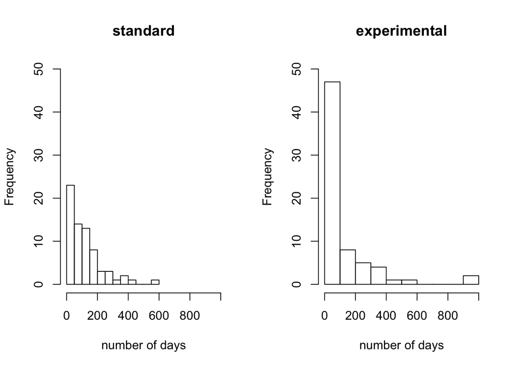

# Non-parametric Survival Analysis with the Kaplan-Meier Survival Curve:

To better elucidate trends in this data, I use a survival curve, which plots the probability of survival over time. The Kaplan-Meier curve, shown below, is an empirical, nonparametric analysis to determine the probability of survival over time. The advantage of a nonparametric model is that it does not make assumptions about the data. If this lung cancer data was distributed very unpredictably, then a parametric test could cause us to make erroneous inferences. (However, I will use a parametric test later in this report and compare the results.) Because Kaplan-Meier is based on purely empirical data (ie not inferring any information with a model), it is a conservative estimate of survival probability.

The plot shows the probability of survival over time for all patients, and the dotted lines depict the 95% confidence intervals for the predictions. Probability of survival declines rather rapidly, with more than 50% of patients dying within 200 days of the study.

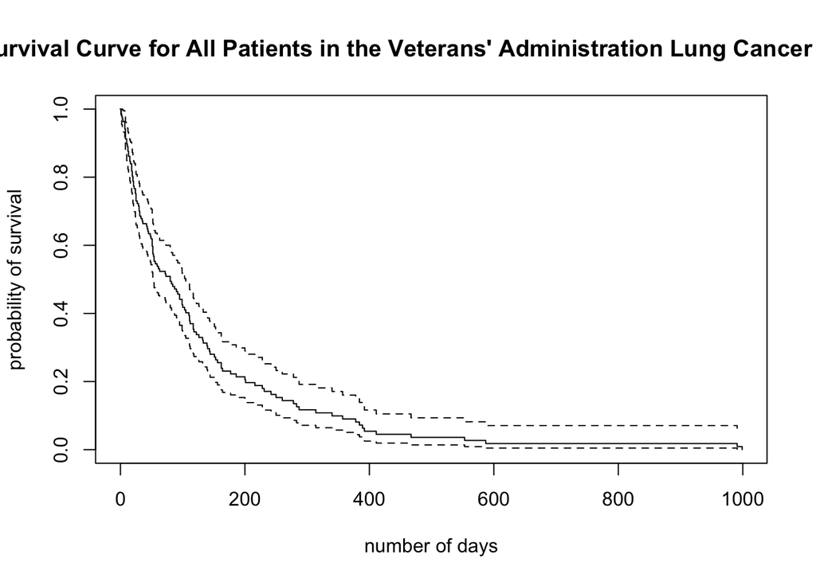

# Hazard rate

I wanted to check whether the probability of survival decreases at a constant rate. The alternative explanation is that the longer a patient in this cohort lives with the disease, the more deadly the disease becomes. The hazard rate answers this question. The plot below shows the rate of death over time. It is derived from the survival curve: the hazard rate is the slope of the survival curve on a log scale. Because the plot below shows a relatively constant decline, I conclude that the rate of death in this cohort is constant over time and, equivalently, that the disease does not increase in lethality over time.

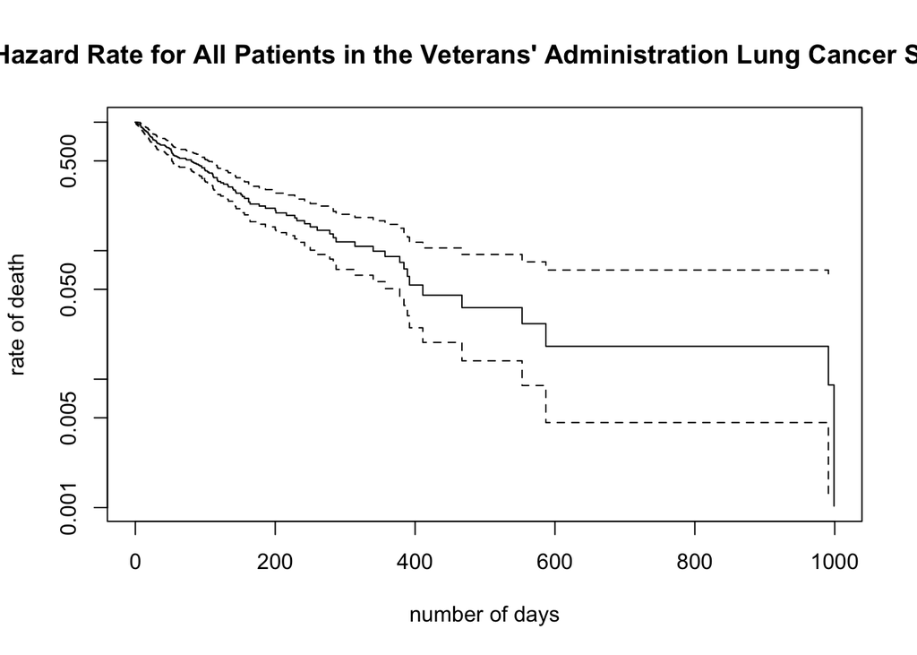

# Survival by Treatment Status

The first survival curve is for all patients grouped together, but we want to find out how survival differs based on treatment. Below, I plotted the separate survival curve for each treatment, with the standard treatment shown in black and the experimental treatment in red. The 95% confidence interval for each survival curve is shown in the same color with a dashed line. Survival does not seem to differ by treatment based on this visualization. Additionally, the 95% confidence intervals from both treatments overlap each other, which means the estimates of each survival curve are most often not separate from each other. These two observations about the plot suggest that treatment is not associated with differntial survival.

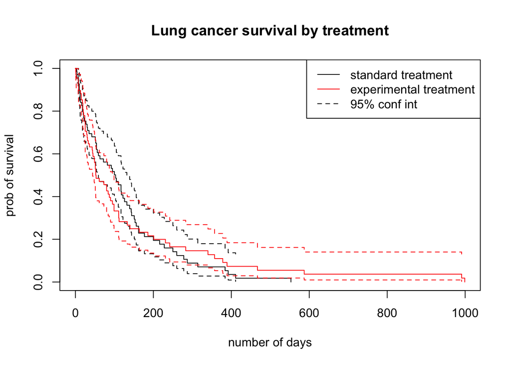

# Survival by Cell Type

In contrast to the comparison of the different treatments, the comparison of survival by cell type suggests that this factor may be associated with differential survival. Patients with squamous cell types survive longer on average, followed by large, smallcell, and adeno cell types. Surival for patiens with smallcell and adeno are quite similar. It should also be noted that the two patients with the longest survival time (of 999 and 991 days) mentioned earlier had squamous celltypes. While these potential outliers do not drive the trend of this nonparametric test (an advantage of a nonparametric test), it is something we should keep in mind as a potential influencer of coefficients for the following parametric tests.

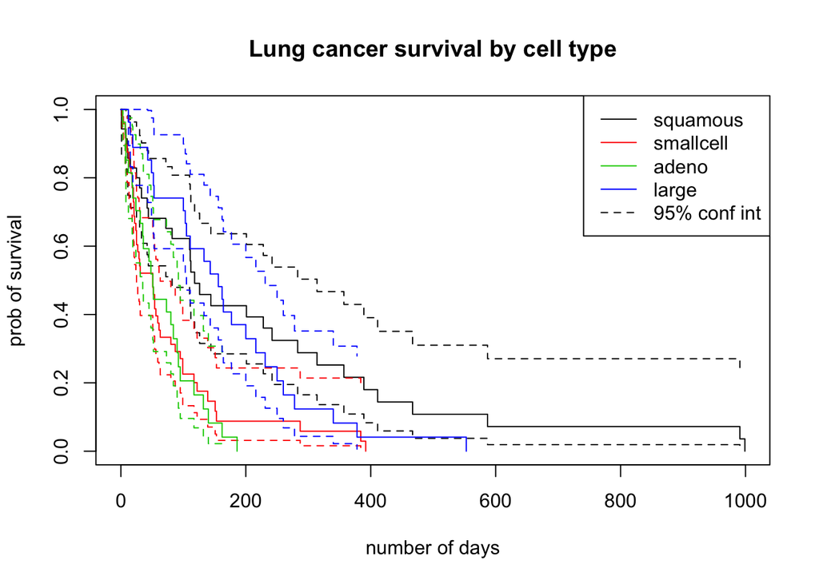

# Fitting a Cox Model

By separating the data into groups by treatment status and celltype and then fitting a Kaplan-Meier survival curve, some trends emerged. The survival curves suggest that the patients in the two treatments do not have different probabilities of survival, while patients with different cancer cell types do have different probabilities of survival. Thus, it will be useful to quantify how these factors affect survival time. For now, I still do not want to assume that the survival data follows a predictable distribution, and so I will use the Cox model of proportional hazards to modify the survival curves generated above by linear predictors for the factors of interest. The Cox model allows for adjusting the intercepts of the survival curve based on a factor, and it helps determine how much each factor contributes to survival.

I first determined which factors significantly affect survival. I included all factors in the model: treatment, age, celltype, Karnofsky score, prior treatment, and diagnosis time. Of these factors, celltype and Karnofsky score significantly affect survival. This means patients with differnet celltypes and Karnofsky scores significantly differ in their survival probabilities over time.

The full Cox model: survival ~ treatment + age + cell type + prior diagnosis + diagnosis time + Karnofsky score

Reduced model based on significant factors: survival ~ cell type + Karnofsky score

[output not shown]

Because cell type and Karnofsky score are the only factors that alter survival time, I took out all other factors from the model. The revised model now includes only Karnofsky score and celltype as contributing to survival time. To make sure this model was appropriate, I used an ANOVA to compare the model with the original associated factors against the reduced model. The results are shown below. The high p-value of the chi square test for the model comparison means that the additional factors do not add significantly to the prediction of survival time.

```
## Analysis of Deviance Table
##  Cox model: response is  Surv(time, status)
##  Model 1: ~ trt + age + celltype + prior + diagtime + karno
##  Model 2: ~ celltype + karno
##    loglik  Chisq Df P(>|Chi|)
## 1 -474.40
## 2 -475.76 2.7322  4    0.6036
```

The survival curves below are generated from the predictions of the model. The survival curves based on predictions look similar to the empirical Kaplan-Meier curves. These multiple lines of supporting evidence strenghten the conclusions that cell type affects survival.

I also show the predictions of survival for Karnofsky scores. Because the score ranges from 0-100, it was difficult to display predictions for each score. I instead grouped the scores into bins of 25, with scores of 0-25 in bin 1, 26-50 in bin 2, etc. Although this method loses resolution for predicting survival for each specific score, it provides a close enough comparison and is advantageous for displaying and comparing survival curves.

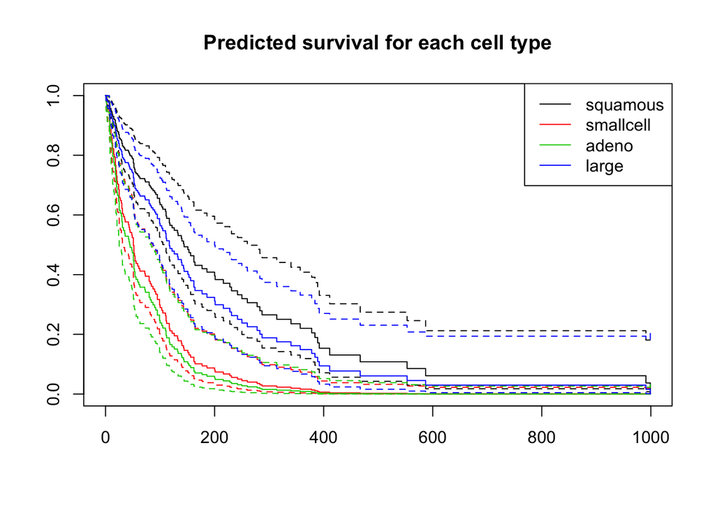

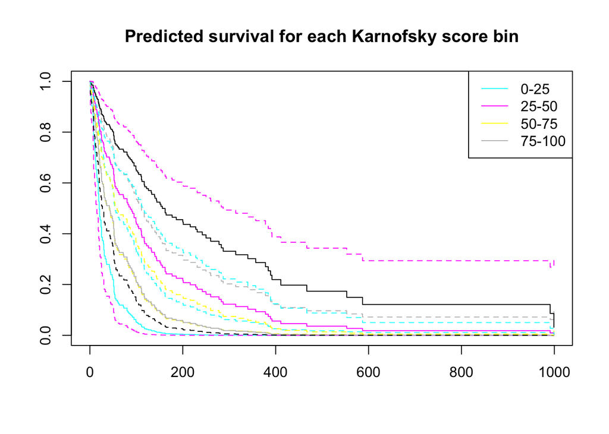

# Parametric Survival Analysis Through Maximum Likelihood Methods

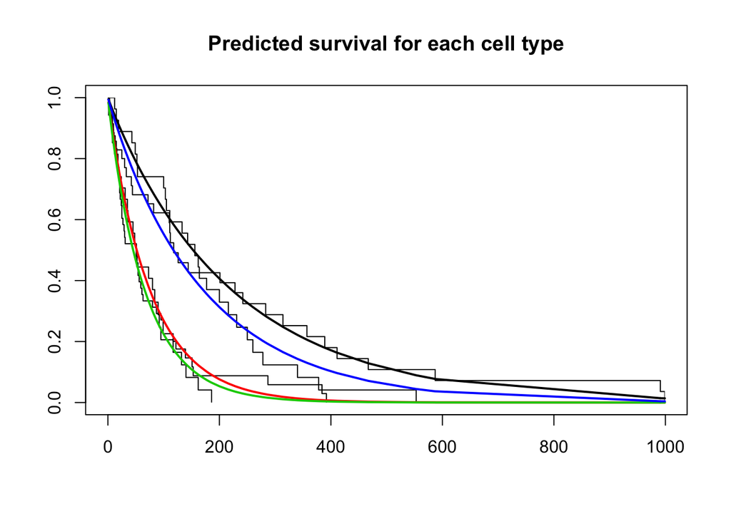

# Conclusion

In conclusion, I find that cell type is significantly associated with survival, as well as Karnofsky score. The experimental treatment was not significantly different in survival from the standard treatment.